# Lab 08 - Text Mining/NLP

# Learning goals

- Use `unnest_tokens()` and `unnest_ngrams()` to extract tokens and ngrams from text
- Use dplyr and ggplot2 to analyze and visualize text data
- Try a theme model using `topicmodels`

# Lab description

For this lab we will be working with the medical record transcriptions from https://www.mtsamples.com/ available at https://github.com/JSC370/JSC370-2025/tree/main/data/medical_transcriptions.

# Deliverables

1. Questions 1-7 answered, knit to pdf or html output uploaded to Quercus.
2. Render the Rmarkdown document using `github_document` and add it to your github site. Add link to github site in your html.

### Setup packages

You should load in `tidyverse`, (or `data.table`), `tidytext`, `wordcloud2`, `tm`, and `topicmodels`.

## Read in the Medical Transcriptions

Loading in reference transcription samples from https://www.mtsamples.com/

```r
library(tidytext)
library(tidyverse)
library(wordcloud2)
library(tm)
library(topicmodels)

mt_samples <- read_csv("https://raw.githubusercontent.com/JSC370/JSC370-2025/main/data/medical_transcriptions/mtsamples.csv")
mt_samples <- mt_samples |>
  select(description, medical_specialty, transcription)

head(mt_samples)
```

```
## # A tibble: 6 × 3
##   description                                    medical_specialty transcription
##   <chr>                                          <chr>             <chr>
## 1 A 23-year-old white female presents with comp… Allergy / Immuno… "SUBJECTIVE:…
## 2 Consult for laparoscopic gastric bypass.       Bariatrics        "PAST MEDICA…
## 3 Consult for laparoscopic gastric bypass.       Bariatrics        "HISTORY OF …
## 4 2-D M-Mode. Doppler.                           Cardiovascular /… "2-D M-MODE:…
## 5 2-D Echocardiogram                             Cardiovascular /… "1.  The lef…
## 6 Morbid obesity.  Laparoscopic antecolic anteg… Bariatrics        "PREOPERATIV…
```

## Question 1: What specialties do we have?

We can use `count()` from `dplyr` to figure out how many different medical specialties are in the data. Are these categories related? overlapping? evenly distributed? Make a bar plot.

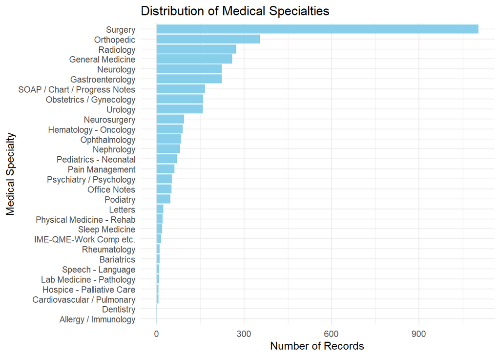

```r
mt_samples |>
  count(medical_specialty, sort = TRUE) |>
  ggplot(aes(fct_reorder(medical_specialty, n), n)) +
  geom_col(fill= "skyblue") +
  coord_flip() +
  labs(title = "Distribution of Medical Specialties",
       x = "Medical Specialty",
       y = "Number of Records") +
  theme_minimal()
```

## The bar plot shows an uneven distribution of medical specialties, with Surgery having the highest number of records, followed by Orthopedic, Radiology, and General Medicine. There is a steep drop-off in frequency after the top few categories, indicating that some specialties are well-represented, while others have very few records.

## Question 2: Tokenize

- Tokenize the the words in the `transcription` column
- Count the number of times each token appears
- Visualize the top 20 most frequent words with a bar plot
- Create a word cloud of the top 20 most frequent words

### Explain what we see from this result. Does it makes sense? What insights (if any) do we get?

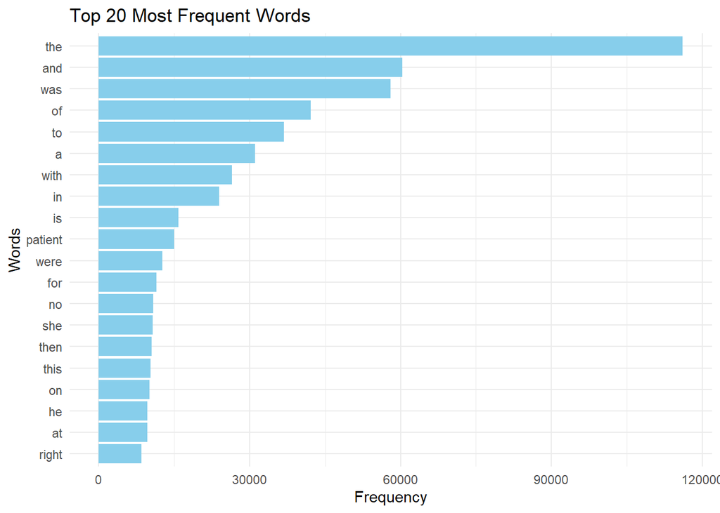

```r
tokens <- mt_samples |>
  select(transcription) |>
  unnest_tokens(word, transcription) |>
  group_by(word) |>
  summarize(word_frequency = n()) |>
  arrange(across(word_frequency, desc)) |>
  head(20)

tokens |>
  ggplot(aes(fct_reorder(word, word_frequency), word_frequency)) +
  geom_bar(stat="identity", fill = "skyblue") +
  coord_flip() +
    labs(title = "Top 20 Most Frequent Words",
       x = "Words",
       y = "Frequency") +
  theme_minimal()
```

The most frequent words in the dataset are common stopwords (e.g., the, and, was), which do not provide meaningful insights into medical transcriptions.

```r
tokens |>
  count(word, sort=TRUE) |>
  wordcloud2(size=0.4, color="random-light", backgroundColor="skyblue")
```

[interactive chart not shown]

## Question 3: Stopwords

- Redo Question 2 but remove stopwords
- Check `stopwords()` library and `stop_words` in `tidytext`
- Use regex to remove numbers as well
- Try customizing your stopwords list to include 3-4 additional words that do not appear informative

### What do we see when you remove stopwords and then when you filter further? Does it give us a better idea of what the text is about?

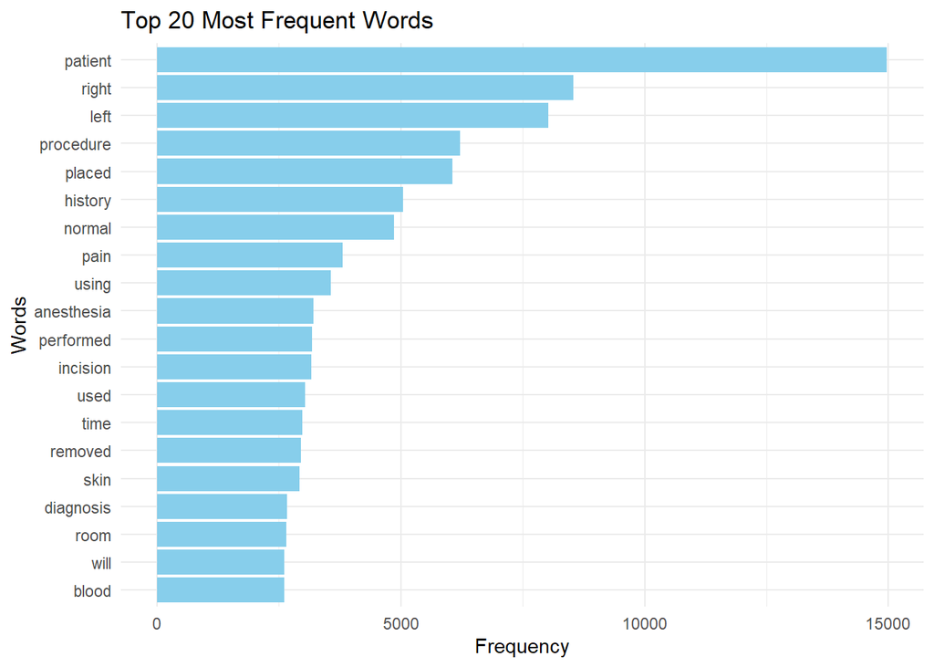

```r
# head(stopwords("english"))
# length(stopwords("english"))
# head(stop_words)

custom_stopwords <- c("noted", "also", "well")

tokens <- mt_samples |>
  select(transcription) |>
  unnest_tokens(word, transcription) |>
  # anti_join(stop_words, by="word") |>
  filter(!word %in% stopwords("english")) |>
  filter(!word %in% custom_stopwords) |>
  filter(!str_detect(word, "^[0-9]+$")) |> # [[:digit]]+
  group_by(word) |>
  summarize(word_frequency = n()) |>
  arrange(across(word_frequency, desc)) |>
  head(20)

tokens |>
  ggplot(aes(fct_reorder(word, word_frequency), word_frequency)) +
  geom_bar(stat="identity", fill = "skyblue") +
  coord_flip() +
  labs(title = "Top 20 Most Frequent Words",
     x = "Words",
     y = "Frequency") +
  theme_minimal()
```

After removing stopwords, the most frequent words now include medical-specific terms like patient, procedure and anesthesia, which provide a clearer insight into the content of medical transcriptions. This filtering helps eliminate common but uninformative words, making it easier to identify key themes and terminology used in clinical records.

```r
tokens |>
  count(word, sort=TRUE) |>
  wordcloud2(size=0.4, color="random-light", backgroundColor="skyblue")
```

[interactive chart not shown]

## Question 4: ngrams

Repeat question 2, but this time tokenize into bi-grams. How does the result change if you look at tri-grams? Note we need to remove stopwords a little differently. You don’t need to recreate the wordclouds.

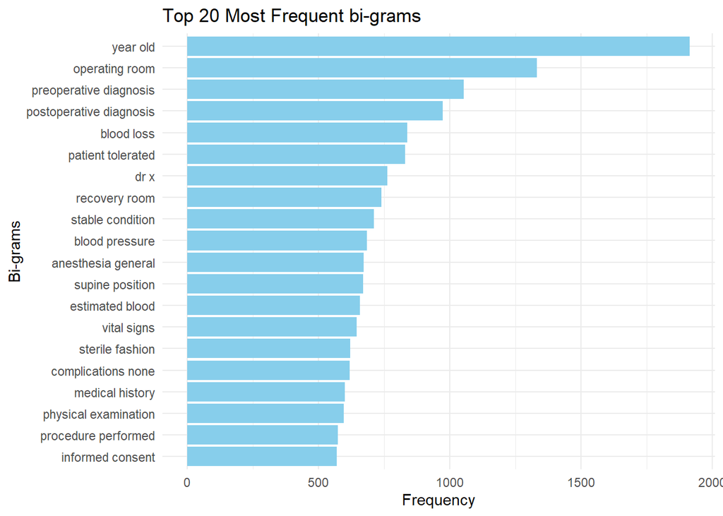

```r
stopwords2 <- c(stopwords("en"), "noted", "also", "well")
sw_start <- paste0("^", paste(stopwords2, collapse=" |^"), "$")
sw_end <- paste0("", paste(stopwords2, collapse="$| "), "$")

tokens_bigram <- mt_samples |>
  select(transcription) |>
  unnest_tokens(ngram, transcription, token = "ngrams", n = 2) |>
  filter(!grepl(sw_start, ngram, ignore.case=TRUE))|>
  filter(!grepl(sw_end, ngram, ignore.case=TRUE))|>
  filter(!grepl("[[:digit:]]+", ngram))|>
  group_by(ngram) |>
  summarize(word_frequency=n()) |>
  arrange(across(word_frequency, desc))

tokens_bigram |>
  head(20) |>
  ggplot(aes(x = fct_reorder(ngram, word_frequency), y = word_frequency)) +
           geom_col(fill="skyblue")+
           coord_flip()+
            labs(title = "Top 20 Most Frequent bi-grams",
             x = "Bi-grams",
             y = "Frequency") +
           theme_minimal()
```

Prof said only need to do bi-grams during lab XD.

## Question 5: Examining words

Using the results from the bigram, pick a word and count the words that appear before and after it, and create a plot of the top 20.

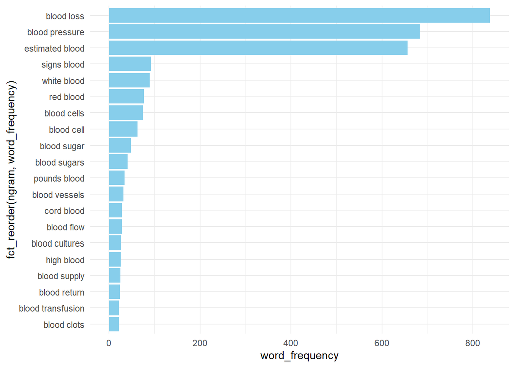

```r
library(stringr)
# e.g. patient, blood, preoperative...
tokens_bigram |>
  filter(str_detect(ngram, regex("\\sblood$|^blood\\s"))) |>
    mutate(word = str_remove(ngram, "blood"),
         word = str_remove_all(word, " ")) |>
  group_by(word)|>
  head(20) |>
  ggplot(aes(x = fct_reorder(ngram, word_frequency), y = word_frequency)) +
  geom_col(fill="skyblue")+
  coord_flip()+
  theme_minimal()
```

## Question 6: Words by Specialties

Which words are most used in each of the specialties? You can use `group_by()` and `top_n()` from `dplyr` to have the calculations be done within each specialty. Remember to remove stopwords. How about the 5 most used words?

```r
mt_samples |>
   unnest_tokens(word, transcription) |>
  filter(!word %in% stopwords("english")) |>
  filter(!word %in% custom_stopwords) |>
  filter(!str_detect(word, "^[0-9]+$")) |> # [[:digit]]+
   group_by(medical_specialty) |>
   count(word,sort=TRUE) |>
  top_n(20, n)
```

```
## # A tibble: 693 × 3
## # Groups:   medical_specialty [30]
##    medical_specialty word           n
##    <chr>             <chr>      <int>
##  1 Surgery           patient     4855
##  2 Surgery           left        3263
##  3 Surgery           right       3261
##  4 Surgery           procedure   3243
##  5 Surgery           placed      3025
##  6 Surgery           using       1754
##  7 Orthopedic        patient     1711
##  8 Surgery           anesthesia  1687
##  9 Surgery           incision    1641
## 10 Surgery           removed     1574
## # ℹ 683 more rows
```

## Question 7: Topic Models

See if there are any themes in the data by using a topic model (LDA).

- you first need to create a document term matrix
- then you can try the LDA function in `topicmodels`. Try different k values.
- create a facet plot of the results from the LDA (see code from lecture)

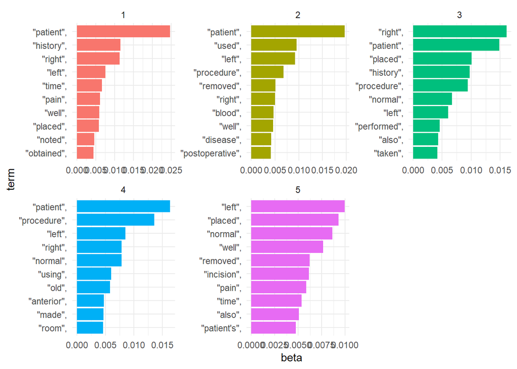

```r
transcripts_dtm <- mt_samples |>
  select(transcription) |>
  unnest_tokens(word, transcription) |>
  filter(!word %in% stopwords("en")) |>
  filter(!str_detect(word, "[[:digit:]]+")) |>
  DocumentTermMatrix()


transcripts_dtm <- as.matrix(transcripts_dtm)

transcripts_lda <- LDA(transcripts_dtm, k=5, control = list(seed=370))

transcripts_top_terms <-
  tidy(transcripts_lda, matrix="beta")|>
  group_by(topic) |>
  slice_max(beta, n=10) |>
  ungroup()|>
  arrange(topic, -beta)

transcripts_top_terms |>
  mutate(term=reorder_within(term, beta, topic)) |>
  ggplot(aes(beta, term, fill=factor(topic))) +
  geom_col(show.legend=FALSE)+
  facet_wrap(~topic, scales="free")+
  scale_y_reordered()+
  theme_minimal()
```